# Reproducible Research: Peer Assessment 1

### Note - the following packages are needed

- ggplot2
- zoo

```r
#install.packages("zoo")
library(ggplot2)
library(zoo)
par( mfrow = c( 1, 1 ) )
```

## Loading and preprocessing the data

### 1. Load the data (i.e. read.csv())

```r
data <- read.csv("activity.csv");
summary(data)
```

```
##      steps               date          interval
##  Min.   :  0.0   2012-10-01:  288   Min.   :   0
##  1st Qu.:  0.0   2012-10-02:  288   1st Qu.: 589
##  Median :  0.0   2012-10-03:  288   Median :1178
##  Mean   : 37.4   2012-10-04:  288   Mean   :1178
##  3rd Qu.: 12.0   2012-10-05:  288   3rd Qu.:1766
##  Max.   :806.0   2012-10-06:  288   Max.   :2355
##  NA's   :2304    (Other)   :15840
```

```r
head(data)
```

```
##   steps       date interval
## 1    NA 2012-10-01        0
## 2    NA 2012-10-01        5
## 3    NA 2012-10-01       10
## 4    NA 2012-10-01       15
## 5    NA 2012-10-01       20
## 6    NA 2012-10-01       25
```

### 2.Process/transform the data (if necessary) into a format suitable for your analysis

No need to tranform data at this time. NA are ignored.

## What is mean total number of steps taken per day?

Note: For this part of the assignment, the missing values in the dataset are ignored.

To get the total number of steps per day the values of steps have to be summed up (aggregated) up over all intervals and grouped by date.

```r
stepsPerDay <- aggregate(steps ~ date, data, sum)
```

To get the total number of steps per interval the values of steps have to be summed up (aggregated) over all days and grouped by interval.

```r
stepsPerInterval <- aggregate(steps ~ interval, data, sum)
```

### 1. Make a histogram of the total number of steps taken each day

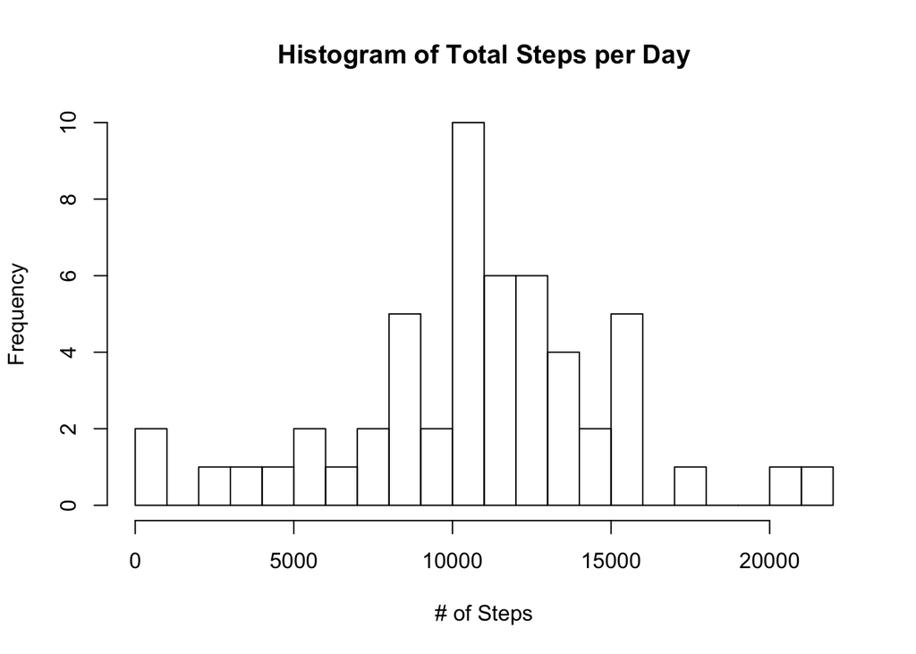

```r
hist(stepsPerDay$steps, breaks=20, main="Histogram of Total Steps per Day",xlab="# of Steps", ylab="Frequency")
```

### 2. Calculate and report the mean and median total number of steps taken per day

```r
meanStepsPerDay <- mean(stepsPerDay$steps)
medianStepsPerDay <- median(stepsPerDay$steps)
```

Mean and median total number of steps taken per day are:

- mean: 1.0766 × 10<sup>4</sup>
- median: 10765

## What is the average daily activity pattern?

```r
avgStepsPerInterval <- aggregate(steps ~ interval, data, mean)
avgStepsPerDay <- aggregate(steps ~ date, data, mean)
```

### Time series plot of the 5-minute interval (x-axis) and the average number of steps taken, averaged across all days (y-axis)

[figure not shown]

```r
plot(avgStepsPerInterval$interval, avgStepsPerInterval$steps, type = "l", main="Avg # of Steps per Interval", xlab="Minute of Day", ylab="# of Steps")
```

### Which 5-minute interval, on average across all the days in the dataset, contains the maximum number of steps?

```r
idx <- which.max(avgStepsPerInterval$steps)
maxRow = avgStepsPerInterval[idx,]
maxValue <- avgStepsPerInterval$steps[idx]
intervalOfMaxAvgValue <- avgStepsPerInterval$interval[idx]
```

The maximum number of steps of 206.1698, on average across all days, occurend on 835

## Imputing missing values

Note that there are a number of days/intervals where there are missing values (coded as NA). The presence of missing days may introduce bias into some calculations or summaries of the data.

### Calculate and report the total number of missing values in the dataset (i.e. the total number of rows with NAs)

```r
idxOfRowsWithNA <- is.na(data$steps)
dataOfNA <- data[is.na(data$steps),]
numRowsWithNA <- nrow(dataOfNA)
```

The dataset has a total number of 2304 rows with missing values.

### Strategy for filling in all of the missing values in the dataset

Calculate the average steps per interval and per day.

```r
avgStepsPerInterval <- aggregate(steps ~ interval, data, mean)
avgStepsPerDay <- aggregate(steps ~ date, data, mean)
```

Devise a strategy for filling in all of the missing values in the dataset. The strategy does not need to be sophisticated. For example, you could use the mean/median for that day, or the mean for that 5-minute interval, etc.

### Create a new dataset that is equal to the original dataset but with the missing data filled in.

To fill missing value I choose to use zoo package. It has many options to fill in missing value. For this purpose na.locf is used. It is a generic function for replacing each NA with the most recent non-NA prior to it.

Note: please make sure the zoo package is installed.

```r
D <- data
D2 <- do.call(rbind, lapply(split(D, D$interval), na.locf))
D2[is.na(D2$steps), 1] <- 0
D2[, 1]  <- sapply(D2[, 1], as.numeric)  # numeric variables should be numeric
```

### Histogram with the total number of steps

Make a histogram of the total number of steps taken each day and Calculate and report the mean and median total number of steps taken per day.

```r
stepsPerDayD2 <- aggregate(steps ~ date, D2, sum)
```

To get the total number of steps per interval the values of steps have to be summed up (aggregated) over all days and grouped by interval.

```r
stepsPerIntervalD2 <- aggregate(steps ~ interval, D2, sum)
```